# DATA 621 - Homework5 - Wine Sales Prediction Count Regression Model

Soumya Ghosh

May 10, 2020

## Libraries

```r
library(kableExtra)
library(tidyverse)
library(ggplot2)
library(dplyr)
library(MASS)
library(corrplot)
library(RColorBrewer)
library(GGally)
library(ggResidpanel)
library(psych)
library(mice)
library(reshape2)
library(cowplot)
library(car)
library(caTools)
library(VIM)
library(broom)
library(pROC)
library(caret)
library(geoR)
library(moments)
library(glmulti)
library(pscl)
```

## Introduction

In this homework assignment, we will explore, analyze and model a data set containing information on approximately 12,000 commercially available wines. The variables are mostly related to the chemical properties of the wine being sold. The response variable is the number of sample cases of wine that were purchased by wine distribution companies after sampling a wine. These cases would be used to provide tasting samples to restaurants and wine stores around the United States. The more sample cases purchased, the more likely is a wine to be sold at a high end restaurant. A large wine manufacturer is studying the data in order to predict the number of wine cases ordered based upon the wine characteristics. If the wine manufacturer can predict the number of cases, then that manufacturer will be able to adjust their wine offering to maximize sales.

Our dataset consists of 15 variables about different qualities. A wine producer might be able to use this data, along with the target variable, number of cases purchased by restaurants, to determine what qualities consumers are looking for in wines and to be able to plan accordingly.

```r
vr <- c("INDEX", "TARGET", "AcidIndex", "Alcohol", "Chlorides", "CitricAcid", "Density", "FixedAcidity", "FreeSulfurDioxide", "LabelAppeal", "ResidualSugar", "STARS", "Sulphates", "TotalSulfurDioxide", "VolatileAcidity", "pH")

def <- c("Identification Variable (do not use)", "Number of Cases Purchased", "Proprietary method of testing total acidity of wine by using a weighted average", "Alcohol Content", "Chloride content of wine", "Citric Acid Content", "Density of Wine", "Fixed Acidity of Wine", "Sulfur Dioxide content of wine", "Marketing Score indicating the appeal of label design for consumers. High numbers suggest customers like the label design. Negative numbers suggest customes don't like the design.", "Residual Sugar of wine", "Wine rating by a team of experts. 4 Stars = Excellent, 1 Star = Poor", "Sulfate conten of wine", "Total Sulfur Dioxide of Wine", "Volatile Acid content of wine", "pH of wine")

te <- c("None", "None", "", "",  "", "", "", "",  "", "Many consumers purchase based on the visual appeal of the wine label design. Higher numbers suggest better sales", "", "A high number of stars suggests high sales",  "", "", "", "")

kable(cbind(vr, def, te), col.names = c("Variable Name", "Definition", "Theoretical Effect")) %>% kable_styling(bootstrap_options = c("striped", "hover", "condensed", "responsive")) %>% scroll_box(width="100%",height="300px")
```

| Variable Name | Definition | Theoretical Effect |
| --- | --- | --- |
| INDEX | Identification Variable (do not use) | None |
| TARGET | Number of Cases Purchased | None |
| AcidIndex | Proprietary method of testing total acidity of wine by using a weighted average |  |
| Alcohol | Alcohol Content |  |
| Chlorides | Chloride content of wine |  |
| CitricAcid | Citric Acid Content |  |
| Density | Density of Wine |  |
| FixedAcidity | Fixed Acidity of Wine |  |
| FreeSulfurDioxide | Sulfur Dioxide content of wine |  |
| LabelAppeal | Marketing Score indicating the appeal of label design for consumers. High numbers suggest customers like the label design. Negative numbers suggest customes don’t like the design. | Many consumers purchase based on the visual appeal of the wine label design. Higher numbers suggest better sales |
| ResidualSugar | Residual Sugar of wine |  |
| STARS | Wine rating by a team of experts. 4 Stars = Excellent, 1 Star = Poor | A high number of stars suggests high sales |
| Sulphates | Sulfate conten of wine |  |
| TotalSulfurDioxide | Total Sulfur Dioxide of Wine |  |
| VolatileAcidity | Volatile Acid content of wine |  |
| pH | pH of wine |  |

## Objective

Our objective is to build a count regression model to predict the number of cases of wine that will be sold given certain properties of the wine. HINT: Sometimes, the fact that a variable is missing is actually predictive of the target. You can only use the variables given to you (or variables that you derive from the variables provided).

## Data Load

Loaded Training and Evalutaion data sets into respective data frames.

```r
train_df <- read.csv("https://raw.githubusercontent.com/soumya2g/CUNYDataMiningHomeWork/master/HomeWork_5/DataFiles/wine-training-data.csv")

eval_df <- read.csv("https://raw.githubusercontent.com/soumya2g/CUNYDataMiningHomeWork/master/HomeWork_5/DataFiles/wine-evaluation-data.csv")
```

## Training Data

Sample snapshot of training data frame -

```r
head(train_df, 20) %>% kable() %>% kable_styling(bootstrap_options = c("striped", "hover", "condensed", "responsive")) %>% scroll_box(width="100%",height="300px")
```

| ï..INDEX | TARGET | FixedAcidity | VolatileAcidity | CitricAcid | ResidualSugar | Chlorides | FreeSulfurDioxide | TotalSulfurDioxide | Density | pH | Sulphates | Alcohol | LabelAppeal | AcidIndex | STARS |
| --- | --- | --- | --- | --- | --- | --- | --- | --- | --- | --- | --- | --- | --- | --- | --- |
| 1 | 3 | 3.2 | 1.160 | -0.98 | 54.20 | -0.567 | NA | 268 | 0.99280 | 3.33 | -0.59 | 9.9 | 0 | 8 | 2 |
| 2 | 3 | 4.5 | 0.160 | -0.81 | 26.10 | -0.425 | 15 | -327 | 1.02792 | 3.38 | 0.70 | NA | -1 | 7 | 3 |
| 4 | 5 | 7.1 | 2.640 | -0.88 | 14.80 | 0.037 | 214 | 142 | 0.99518 | 3.12 | 0.48 | 22.0 | -1 | 8 | 3 |
| 5 | 3 | 5.7 | 0.385 | 0.04 | 18.80 | -0.425 | 22 | 115 | 0.99640 | 2.24 | 1.83 | 6.2 | -1 | 6 | 1 |
| 6 | 4 | 8.0 | 0.330 | -1.26 | 9.40 | NA | -167 | 108 | 0.99457 | 3.12 | 1.77 | 13.7 | 0 | 9 | 2 |
| 7 | 0 | 11.3 | 0.320 | 0.59 | 2.20 | 0.556 | -37 | 15 | 0.99940 | 3.20 | 1.29 | 15.4 | 0 | 11 | NA |
| 8 | 0 | 7.7 | 0.290 | -0.40 | 21.50 | 0.060 | 287 | 156 | 0.99572 | 3.49 | 1.21 | 10.3 | 0 | 8 | NA |
| 11 | 4 | 6.5 | -1.220 | 0.34 | 1.40 | 0.040 | 523 | 551 | 1.03236 | 3.20 | NA | 11.6 | 1 | 7 | 3 |
| 12 | 3 | 14.8 | 0.270 | 1.05 | 11.25 | -0.007 | -213 | NA | 0.99620 | 4.93 | 0.26 | 15.0 | 0 | 6 | NA |
| 13 | 6 | 5.5 | -0.220 | 0.39 | 1.80 | -0.277 | 62 | 180 | 0.94724 | 3.09 | 0.75 | 12.6 | 0 | 8 | 4 |
| 14 | 0 | -17.2 | 0.520 | 0.15 | -33.80 | -0.022 | 551 | 65 | 0.99340 | 4.31 | 0.56 | 13.1 | 1 | 5 | 1 |
| 15 | 4 | 9.0 | 0.220 | 0.49 | 10.40 | -0.150 | NA | 195 | 1.05918 | 3.01 | -0.40 | 10.2 | 0 | 10 | 2 |
| 16 | 3 | 6.0 | 0.330 | -1.06 | 3.00 | 0.518 | 5 | 378 | 0.96643 | 3.55 | -0.86 | 3.9 | 1 | 7 | 2 |
| 17 | 7 | 14.9 | 0.320 | 0.34 | 1.30 | 0.042 | 20 | NA | 0.95523 | 2.93 | 2.16 | 12.0 | 2 | 8 | 3 |
| 19 | 4 | 21.8 | 0.510 | 1.83 | 2.90 | -0.165 | -49 | 45 | 0.99740 | 6.02 | 2.23 | 12.1 | 0 | 9 | NA |
| 20 | 0 | 5.7 | 0.500 | -0.11 | 6.10 | 0.071 | 234 | -331 | 0.99780 | 3.35 | NA | 6.8 | 0 | 8 | NA |
| 22 | 0 | 7.9 | 0.600 | 0.06 | 50.40 | 0.069 | 15 | 339 | 0.99640 | 3.30 | 0.46 | 3.9 | 1 | 9 | NA |
| 23 | 4 | -1.3 | 0.220 | 2.95 | -53.00 | 0.541 | -85 | -266 | 0.99672 | 3.61 | 0.82 | 10.0 | 0 | 8 | 3 |
| 24 | 5 | 10.0 | 0.230 | 0.27 | 14.10 | 0.033 | -188 | 229 | 0.99880 | 3.14 | 0.88 | 11.0 | 1 | 11 | 2 |
| 25 | 4 | 6.8 | 0.475 | -0.20 | -50.75 | 0.047 | -88 | 508 | 0.99403 | 3.23 | 0.35 | 18.3 | -1 | 8 | 2 |

```r
str(train_df)
```

```
## 'data.frame':    12795 obs. of  16 variables:
##  $ ï..INDEX          : int  1 2 4 5 6 7 8 11 12 13 ...
##  $ TARGET            : int  3 3 5 3 4 0 0 4 3 6 ...
##  $ FixedAcidity      : num  3.2 4.5 7.1 5.7 8 11.3 7.7 6.5 14.8 5.5 ...
##  $ VolatileAcidity   : num  1.16 0.16 2.64 0.385 0.33 0.32 0.29 -1.22 0.27 -0.22 ...
##  $ CitricAcid        : num  -0.98 -0.81 -0.88 0.04 -1.26 0.59 -0.4 0.34 1.05 0.39 ...
##  $ ResidualSugar     : num  54.2 26.1 14.8 18.8 9.4 ...
##  $ Chlorides         : num  -0.567 -0.425 0.037 -0.425 NA 0.556 0.06 0.04 -0.007 -0.277 ...
##  $ FreeSulfurDioxide : num  NA 15 214 22 -167 -37 287 523 -213 62 ...
##  $ TotalSulfurDioxide: num  268 -327 142 115 108 15 156 551 NA 180 ...
##  $ Density           : num  0.993 1.028 0.995 0.996 0.995 ...
##  $ pH                : num  3.33 3.38 3.12 2.24 3.12 3.2 3.49 3.2 4.93 3.09 ...
##  $ Sulphates         : num  -0.59 0.7 0.48 1.83 1.77 1.29 1.21 NA 0.26 0.75 ...
##  $ Alcohol           : num  9.9 NA 22 6.2 13.7 15.4 10.3 11.6 15 12.6 ...
##  $ LabelAppeal       : int  0 -1 -1 -1 0 0 0 1 0 0 ...
##  $ AcidIndex         : int  8 7 8 6 9 11 8 7 6 8 ...
##  $ STARS             : int  2 3 3 1 2 NA NA 3 NA 4 ...
```

## PART I: Data Exploration

### Data Cleansing & Transoformation

We wanted to start off data exploration process with cleaning up the issues that we observed above -

```r
# Exclude INDEX attribute from the data frame
train_df <- train_df %>% dplyr::select(-"ï..INDEX")
```

### Descriptive Statistical Summary

Next step of data exploration process involves high level descriptive statistical summary and missing/exception value analysis.

```r
stat_summary <- function(df){
  df %>%
    summary() %>%
    kable() %>%
    kable_styling(bootstrap_options = c("striped", "hover", "condensed", "responsive")) %>%
    scroll_box(width="100%",height="400px")
}
stat_summary(train_df)
```

[output not shown]

VolatileAcidity

CitricAcid

ResidualSugar

Chlorides

FreeSulfurDioxide

TotalSulfurDioxide

[output not shown]

[output not shown]

Sulphates

[output not shown]

LabelAppeal

AcidIndex

[output not shown]

Min. :-18.100

Min. :-2.7900

Min. :-3.2400

Min. :-127.800

Min. :-1.1710

Min. :-555.00

Min. :-823.0

Min. :0.8881

Min. :0.480

Min. :-3.1300

Min. :-4.70

Min. :-2.000000

Min. : 4.000

Min. :1.000

1st Qu.: 5.200

1st Qu.: 0.1300

1st Qu.: 0.0300

1st Qu.: -2.000

1st Qu.:-0.0310

1st Qu.: 0.00

1st Qu.: 27.0

1st Qu.:0.9877

1st Qu.:2.960

1st Qu.: 0.2800

1st Qu.: 9.00

1st Qu.:-1.000000

1st Qu.: 7.000

1st Qu.:1.000

Median : 6.900

Median : 0.2800

Median : 0.3100

Median : 3.900

Median : 0.0460

Median : 30.00

Median : 123.0

Median :0.9945

Median :3.200

Median : 0.5000

Median :10.40

Median : 0.000000

Median : 8.000

Median :2.000

Mean : 7.076

Mean : 0.3241

Mean : 0.3084

Mean : 5.419

Mean : 0.0548

Mean : 30.85

Mean : 120.7

Mean :0.9942

Mean :3.208

Mean : 0.5271

Mean :10.49

Mean :-0.009066

Mean : 7.773

Mean :2.042

3rd Qu.: 9.500

3rd Qu.: 0.6400

3rd Qu.: 0.5800

3rd Qu.: 15.900

3rd Qu.: 0.1530

3rd Qu.: 70.00

3rd Qu.: 208.0

3rd Qu.:1.0005

3rd Qu.:3.470

3rd Qu.: 0.8600

3rd Qu.:12.40

3rd Qu.: 1.000000

3rd Qu.: 8.000

3rd Qu.:3.000

Max. : 34.400

Max. : 3.6800

Max. : 3.8600

Max. : 141.150

Max. : 1.3510

Max. : 623.00

Max. :1057.0

Max. :1.0992

Max. :6.130

Max. : 4.2400

Max. :26.50

Max. : 2.000000

Max. :17.000

Max. :4.000

NA

NA

NA

NA’s :616

NA’s :638

NA’s :647

NA’s :682

NA

NA’s :395

NA’s :1210

NA’s :653

NA

NA

NA’s :3359

From the above we can see that there are certain features with missing values. We will handle these issues in a further step towards improving data quality.

We also used describe() function of ‘psych’ package to summarize additional statistical measurements like Standard Deviation, Skewness, Kurtois, Standard Error etc.

```r
stat_desc <- function(df){
df %>%
    describe() %>%
    kable() %>%
    kable_styling(bootstrap_options = c("striped", "hover", "condensed", "responsive")) %>%  scroll_box(width="100%",height="300px")
}

stat_desc(train_df)
```

|  | vars | n | mean | sd | median | trimmed | mad | min | max | range | skew | kurtosis | se |
| --- | --- | --- | --- | --- | --- | --- | --- | --- | --- | --- | --- | --- | --- |
| TARGET | 1 | 12795 | 3.0290739 | 1.9263682 | 3.00000 | 3.0538244 | 1.4826000 | 0.00000 | 8.00000 | 8.00000 | -0.3263010 | -0.8772457 | 0.0170302 |
| FixedAcidity | 2 | 12795 | 7.0757171 | 6.3176435 | 6.90000 | 7.0736739 | 3.2617200 | -18.10000 | 34.40000 | 52.50000 | -0.0225860 | 1.6749987 | 0.0558515 |
| VolatileAcidity | 3 | 12795 | 0.3241039 | 0.7840142 | 0.28000 | 0.3243890 | 0.4299540 | -2.79000 | 3.68000 | 6.47000 | 0.0203800 | 1.8322106 | 0.0069311 |
| CitricAcid | 4 | 12795 | 0.3084127 | 0.8620798 | 0.31000 | 0.3102520 | 0.4151280 | -3.24000 | 3.86000 | 7.10000 | -0.0503070 | 1.8379401 | 0.0076213 |
| ResidualSugar | 5 | 12179 | 5.4187331 | 33.7493790 | 3.90000 | 5.5800410 | 15.7155600 | -127.80000 | 141.15000 | 268.95000 | -0.0531229 | 1.8846917 | 0.3058158 |
| Chlorides | 6 | 12157 | 0.0548225 | 0.3184673 | 0.04600 | 0.0540159 | 0.1349166 | -1.17100 | 1.35100 | 2.52200 | 0.0304272 | 1.7886044 | 0.0028884 |
| FreeSulfurDioxide | 7 | 12148 | 30.8455713 | 148.7145577 | 30.00000 | 30.9334877 | 56.3388000 | -555.00000 | 623.00000 | 1178.00000 | 0.0063930 | 1.8364966 | 1.3492769 |
| TotalSulfurDioxide | 8 | 12113 | 120.7142326 | 231.9132105 | 123.00000 | 120.8895367 | 134.9166000 | -823.00000 | 1057.00000 | 1880.00000 | -0.0071794 | 1.6746665 | 2.1071703 |
| Density | 9 | 12795 | 0.9942027 | 0.0265376 | 0.99449 | 0.9942130 | 0.0093552 | 0.88809 | 1.09924 | 0.21115 | -0.0186938 | 1.8999592 | 0.0002346 |
| pH | 10 | 12400 | 3.2076282 | 0.6796871 | 3.20000 | 3.2055706 | 0.3854760 | 0.48000 | 6.13000 | 5.65000 | 0.0442880 | 1.6462681 | 0.0061038 |
| Sulphates | 11 | 11585 | 0.5271118 | 0.9321293 | 0.50000 | 0.5271453 | 0.4447800 | -3.13000 | 4.24000 | 7.37000 | 0.0059119 | 1.7525655 | 0.0086602 |
| Alcohol | 12 | 12142 | 10.4892363 | 3.7278190 | 10.40000 | 10.5018255 | 2.3721600 | -4.70000 | 26.50000 | 31.20000 | -0.0307158 | 1.5394949 | 0.0338306 |
| LabelAppeal | 13 | 12795 | -0.0090660 | 0.8910892 | 0.00000 | -0.0099639 | 1.4826000 | -2.00000 | 2.00000 | 4.00000 | 0.0084295 | -0.2622916 | 0.0078777 |
| AcidIndex | 14 | 12795 | 7.7727237 | 1.3239264 | 8.00000 | 7.6431572 | 1.4826000 | 4.00000 | 17.00000 | 13.00000 | 1.6484959 | 5.1900925 | 0.0117043 |
| STARS | 15 | 9436 | 2.0417550 | 0.9025400 | 2.00000 | 1.9711258 | 1.4826000 | 1.00000 | 4.00000 | 3.00000 | 0.4472353 | -0.6925343 | 0.0092912 |

### Missing Value Analysis

Below we have applied imputation technique for the features that has NA values.

```r
## Counts of missing data per feature
train_na_df <- data.frame(apply(train_df, 2, function(x) length(which(is.na(x)))))
train_na_df1 <- data.frame(apply(train_df, 2,function(x) {sum(is.na(x)) / length(x) * 100}))

train_na_df <- cbind(Feature = rownames(train_na_df), train_na_df, train_na_df1)
colnames(train_na_df) <- c('Feature Name','No. of NA Recocrds','Percentage of NA Records')
rownames(train_na_df) <- NULL


train_na_df%>% filter(`No. of NA Recocrds` != 0) %>% arrange(desc(`No. of NA Recocrds`)) %>% kable() %>% kable_styling(bootstrap_options = c("striped", "hover", "condensed", "responsive")) %>% scroll_box(width="100%",height="300px")
```

| Feature Name | No. of NA Recocrds | Percentage of NA Records |
| --- | --- | --- |
| STARS | 3359 | 26.252442 |
| Sulphates | 1210 | 9.456819 |
| TotalSulfurDioxide | 682 | 5.330207 |
| Alcohol | 653 | 5.103556 |
| FreeSulfurDioxide | 647 | 5.056663 |
| Chlorides | 638 | 4.986323 |
| ResidualSugar | 616 | 4.814381 |
| pH | 395 | 3.087143 |

### Imputation

```r
impute_data <- function(df){

  df <- mice(data = df, m = 1, method = "pmm", maxit = 5, seed = 500)
  df <- mice::complete(df, 1)
}

train_df <- impute_data(train_df)
eval_df <- impute_data(eval_df)
```

Below we have applied imputation technique for the features that has NA values per the table above.

### Descriptive Statistical Plots

#### Box Plots

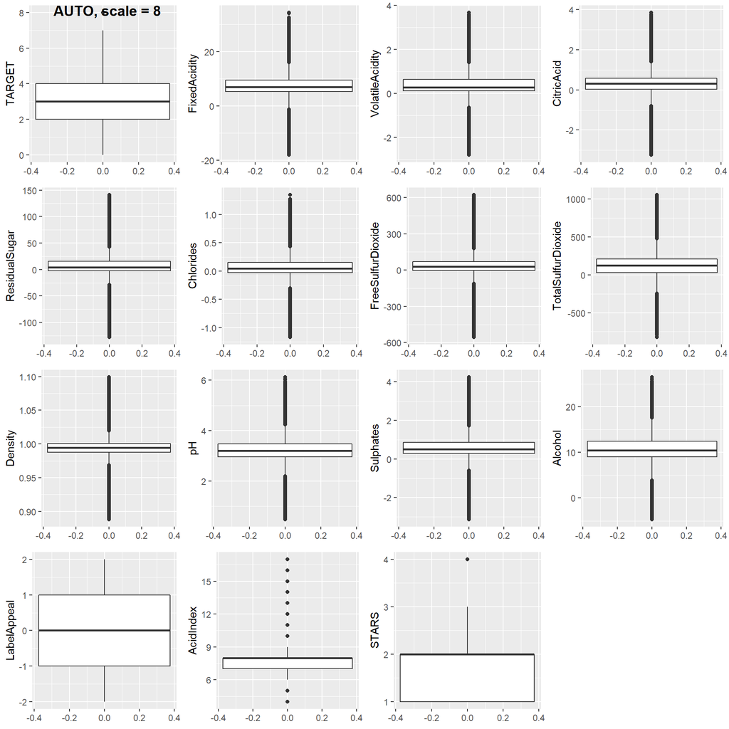

```r
## Box plots:
gb1 <- ggplot(data = train_df, aes(y = TARGET)) + geom_boxplot()
gb2 <- ggplot(data = train_df, aes(y = FixedAcidity)) + geom_boxplot()
gb3 <- ggplot(data = train_df, aes(y = VolatileAcidity)) + geom_boxplot()
gb4 <- ggplot(data = train_df, aes(y = CitricAcid)) + geom_boxplot()
gb5 <- ggplot(data = train_df, aes(y = ResidualSugar)) + geom_boxplot()
gb6 <- ggplot(data = train_df, aes(y = Chlorides)) + geom_boxplot()
gb7 <- ggplot(data = train_df, aes(y = FreeSulfurDioxide)) + geom_boxplot()
gb8 <- ggplot(data = train_df, aes(y = TotalSulfurDioxide)) + geom_boxplot()
gb9 <- ggplot(data = train_df, aes(y = Density)) + geom_boxplot()
gb10 <- ggplot(data = train_df, aes(y = pH)) + geom_boxplot()
gb11 <- ggplot(data = train_df, aes(y = Sulphates)) + geom_boxplot()
gb12 <- ggplot(data = train_df, aes(y = Alcohol)) + geom_boxplot()
gb13 <- ggplot(data = train_df, aes(y = LabelAppeal)) + geom_boxplot()
gb14 <- ggplot(data = train_df, aes(y = AcidIndex)) + geom_boxplot()
gb15 <- ggplot(data = train_df, aes(y = STARS)) + geom_boxplot()


plot_grid(gb1, gb2, gb3, gb4, gb5, gb6, gb7, gb8, gb9, gb10,
          gb11, gb12, gb13, gb14, gb15, labels = "AUTO, scale = 8")
```

#### Density Plots

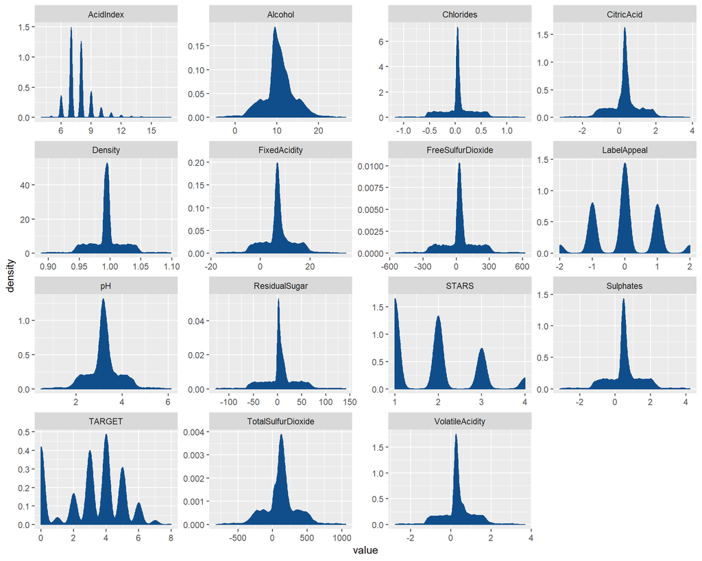

```r
train_df %>% dplyr::select(TARGET,FixedAcidity,VolatileAcidity,CitricAcid,ResidualSugar,Chlorides,FreeSulfurDioxide,TotalSulfurDioxide,Density,pH,Sulphates,Alcohol,LabelAppeal,AcidIndex,STARS) %>%
  gather(variable, value) %>%
  ggplot(., aes(value)) +
  geom_density(fill = "dodgerblue4", color="dodgerblue4") +
  facet_wrap(~variable, scales ="free", ncol = 4) +
  labs(x = element_blank(), y = element_blank())
```

### Observations Summary

The above shows that most of the data is more or less normally distributed. There are some values such as *Sulphates*, *Chlorides*, *VolatileAcidity*, *CitricAcid*, *ResidualSugar*, *FixedAcid*, *FreeSulfurDioxide*, and *TotalSulfurDioxide* that have negative values. After taking a closer look at these data points, it is likely that the creator of this dataset ended up standardizing the data. Because the data is already normally distributed and the test (eval) dataset is also likely structured in this way, we will not be making any adjustments to this data.

It would be interesting to see if there were any correlations between the independent variables to independent variables, and independent variables to the dependent variable.

## PART II: Data Preparation

### Correlation Plot

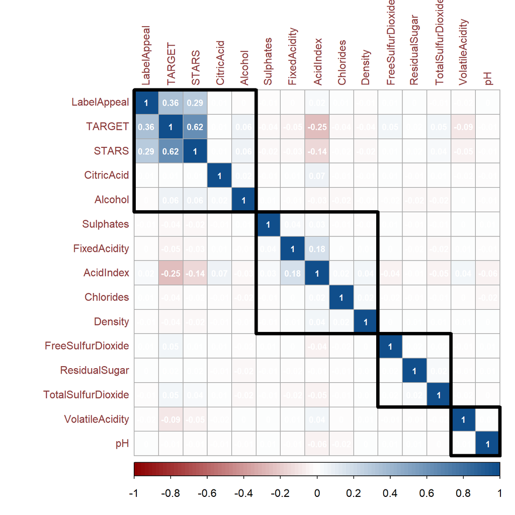

```r
trainnum_df <- dplyr::select_if(train_df, is.numeric)
corrMatrix <- round(cor(trainnum_df),4)

corrMatrix %>% corrplot(., method = "color", outline = T, addgrid.col = "darkgray", order="hclust", addrect = 4, rect.col = "black", rect.lwd = 5,cl.pos = "b", tl.col = "indianred4", tl.cex = 1.0, cl.cex = 1.0, addCoef.col = "white", number.digits = 2, number.cex = 0.8, col = colorRampPalette(c("darkred","white","dodgerblue4"))(100))
```

In the correlation plot above, we see, *STARS* and *LabelAppeal* are most positively correlated variables with the response variable. We expected this because our variable description mentions these variable’s theoretical effect are higher than other variables. Also, we some mild negative correlation between the response variable and *AcidIndex* variable.

## PART III: Building Models

### Test train approach

We have divided the traning dataset into training and test sets using a 80/20 split. We will build our models on the training set and evaluate it on the test set.

```r
set.seed(123)
split <- sample.split(train_df$TARGET, SplitRatio = 0.8)
training_set <- subset(train_df, split == TRUE)
test_set <- subset(train_df, split == FALSE)
```

Below is the list of complete list of variables before we embark on Model building process -

```r
str(training_set)
```

```
## 'data.frame':    10237 obs. of  15 variables:
##  $ TARGET            : int  3 3 5 3 4 0 0 4 6 4 ...
##  $ FixedAcidity      : num  3.2 4.5 7.1 5.7 8 11.3 7.7 6.5 5.5 21.8 ...
##  $ VolatileAcidity   : num  1.16 0.16 2.64 0.385 0.33 0.32 0.29 -1.22 -0.22 0.51 ...
##  $ CitricAcid        : num  -0.98 -0.81 -0.88 0.04 -1.26 0.59 -0.4 0.34 0.39 1.83 ...
##  $ ResidualSugar     : num  54.2 26.1 14.8 18.8 9.4 2.2 21.5 1.4 1.8 2.9 ...
##  $ Chlorides         : num  -0.567 -0.425 0.037 -0.425 0.049 0.556 0.06 0.04 -0.277 -0.165 ...
##  $ FreeSulfurDioxide : num  -8 15 214 22 -167 -37 287 523 62 -49 ...
##  $ TotalSulfurDioxide: num  268 -327 142 115 108 15 156 551 180 45 ...
##  $ Density           : num  0.993 1.028 0.995 0.996 0.995 ...
##  $ pH                : num  3.33 3.38 3.12 2.24 3.12 3.2 3.49 3.2 3.09 6.02 ...
##  $ Sulphates         : num  -0.59 0.7 0.48 1.83 1.77 1.29 1.21 0.83 0.75 2.23 ...
##  $ Alcohol           : num  9.9 13.5 22 6.2 13.7 15.4 10.3 11.6 12.6 12.1 ...
##  $ LabelAppeal       : int  0 -1 -1 -1 0 0 0 1 0 0 ...
##  $ AcidIndex         : int  8 7 8 6 9 11 8 7 8 9 ...
##  $ STARS             : int  2 3 3 1 2 1 1 3 4 1 ...
```

### Build Poisson Regression Models

#### Model 1 (Poisson Regression):

We will start off with a model with all the original variables excluding any derived features -

```r
poisson_model_1 <- glm(TARGET ~ ., family=poisson, data=training_set)
poisson_model_1 <- step(poisson_model_1, direction="backward")
```

```
## Start:  AIC=38426.61
## TARGET ~ FixedAcidity + VolatileAcidity + CitricAcid + ResidualSugar +
##     Chlorides + FreeSulfurDioxide + TotalSulfurDioxide + Density +
##     pH + Sulphates + Alcohol + LabelAppeal + AcidIndex + STARS
##
##                      Df Deviance   AIC
## - ResidualSugar       1    12839 38425
## - FixedAcidity        1    12839 38425
## - Alcohol             1    12840 38426
## <none>                     12839 38427
## - Density             1    12841 38427
## - CitricAcid          1    12841 38427
## - Sulphates           1    12843 38429
## - Chlorides           1    12844 38430
## - FreeSulfurDioxide   1    12846 38432
## - TotalSulfurDioxide  1    12846 38433
## - pH                  1    12847 38433
## - VolatileAcidity     1    12874 38460
## - AcidIndex           1    13247 38833
## - LabelAppeal         1    13307 38893
## - STARS               1    15645 41231
##
## Step:  AIC=38425.09
## TARGET ~ FixedAcidity + VolatileAcidity + CitricAcid + Chlorides +
##     FreeSulfurDioxide + TotalSulfurDioxide + Density + pH + Sulphates +
##     Alcohol + LabelAppeal + AcidIndex + STARS
##
##                      Df Deviance   AIC
## - FixedAcidity        1    12840 38424
## - Alcohol             1    12840 38424
## <none>                     12839 38425
## - Density             1    12841 38425
## - CitricAcid          1    12842 38426
## - Sulphates           1    12844 38428
## - Chlorides           1    12845 38429
## - FreeSulfurDioxide   1    12847 38431
## - TotalSulfurDioxide  1    12847 38431
## - pH                  1    12847 38431
## - VolatileAcidity     1    12874 38458
## - AcidIndex           1    13247 38831
```

[output cut: 26 more lines]

```
##     AcidIndex + STARS
##
##                      Df Deviance   AIC
## <none>                     12841 38423
## - Density             1    12843 38423
## - CitricAcid          1    12844 38424
## - Sulphates           1    12846 38426
## - Chlorides           1    12847 38427
## - FreeSulfurDioxide   1    12849 38429
## - TotalSulfurDioxide  1    12849 38429
## - pH                  1    12849 38429
## - VolatileAcidity     1    12876 38456
## - AcidIndex           1    13267 38847
## - LabelAppeal         1    13309 38889
## - STARS               1    15677 41257
```

```r
summary(poisson_model_1)
```

```
##
## Call:
## glm(formula = TARGET ~ VolatileAcidity + CitricAcid + Chlorides +
##     FreeSulfurDioxide + TotalSulfurDioxide + Density + pH + Sulphates +
##     LabelAppeal + AcidIndex + STARS, family = poisson, data = training_set)
##
## Deviance Residuals:
##     Min       1Q   Median       3Q      Max
## -3.0644  -0.6898   0.1274   0.6338   2.6622
##
## Coefficients:
##                      Estimate Std. Error z value Pr(>|z|)
## (Intercept)         1.581e+00  2.170e-01   7.283 3.27e-13 ***
## VolatileAcidity    -4.351e-02  7.326e-03  -5.940 2.86e-09 ***
## CitricAcid          1.067e-02  6.561e-03   1.627  0.10378
## Chlorides          -4.355e-02  1.774e-02  -2.455  0.01410 *
## FreeSulfurDioxide   1.066e-04  3.828e-05   2.785  0.00535 **
## TotalSulfurDioxide  6.950e-05  2.474e-05   2.809  0.00498 **
## Density            -3.228e-01  2.139e-01  -1.509  0.13131
## pH                 -2.381e-02  8.332e-03  -2.858  0.00426 **
## Sulphates          -1.348e-02  6.133e-03  -2.198  0.02794 *
## LabelAppeal         1.472e-01  6.804e-03  21.631  < 2e-16 ***
## AcidIndex          -1.001e-01  4.991e-03 -20.053  < 2e-16 ***
## STARS               3.371e-01  6.256e-03  53.882  < 2e-16 ***
## ---
## Signif. codes:  0 '***' 0.001 '**' 0.01 '*' 0.05 '.' 0.1 ' ' 1
##
## (Dispersion parameter for poisson family taken to be 1)
##
##     Null deviance: 18291  on 10236  degrees of freedom
## Residual deviance: 12841  on 10225  degrees of freedom
## AIC: 38423
##
## Number of Fisher Scoring iterations: 5
```

#### RMSE Calculation

```r
rmse_calc <- function(actual, predicted) {
  rmse_val <- sqrt(sum((actual - predicted)^2) / length(actual))

  return(rmse_val)
}

### RMSE of first model - training dataset
model1_rmse_train <- mean(rmse_calc(training_set$TARGET, predict(poisson_model_1, newdata = training_set)))
### RMSE of first model - test dataset
model1_rmse_test <- mean(rmse_calc(test_set$TARGET, predict(poisson_model_1, newdata = test_set)))

model1_aic <- poisson_model_1$aic
```

### Model 2 (Poisson Regression Model 2 - Zero-inflated):

“Zero-inflated poisson regression is used to model count data that has an excess of zero counts. Further, theory suggests that the excess zeros are generated by a separate process from the count values and that the excess zeros can be modeled independently. Thus, the zip model has two parts, a poisson count model and the logit model for predicting excess zeros.”

Reference: https://www.theanalysisfactor.com/zero-inflated-poisson-models-for-count-outcomes/

“The Poisson distribution assumes that each count is the result of each Poisson process - a random process that says each counted event is independent and equally likely. If this count variable is used as the outcome of a regression model, we can use Poisson regression to estimate how predictors affect the number of times the devent occurred.”

“But sometimes, it’s just a matter of having too many zeros that a Poisson would predict. In this case, a better solution is often the Zero-Inflated Poisson (ZIP) model.ZIP models assume that some zeros occurred by a Poisson process.The ZIP model fits, simultaneously, two separate regression models. One is a logistic model that models the probability of being eligible for a non-zero count. The other models the size of that count.”

“Both models use the same predictor variables, but estimate their coefficients separately. So the predictors can have vastly different effects on the two processes.”

Below is the second model utilizing ZIP.

```r
poisson_model_2 <- zeroinfl(TARGET ~ ., data = training_set)
summary(poisson_model_2)
```

```
##
## Call:
## zeroinfl(formula = TARGET ~ ., data = training_set)
##
## Pearson residuals:
##      Min       1Q   Median       3Q      Max
## -2.15710 -0.45312  0.02585  0.42737  6.98368
##
## Count model coefficients (poisson with log link):
##                      Estimate Std. Error z value Pr(>|z|)
## (Intercept)         1.434e+00  2.253e-01   6.363 1.97e-10 ***
## FixedAcidity        1.840e-04  9.405e-04   0.196 0.844929
## VolatileAcidity    -1.669e-02  7.561e-03  -2.207 0.027308 *
## CitricAcid         -7.852e-04  6.748e-03  -0.116 0.907369
## ResidualSugar      -6.918e-05  1.743e-04  -0.397 0.691419
## Chlorides          -1.993e-02  1.838e-02  -1.084 0.278182
## FreeSulfurDioxide   1.138e-05  3.878e-05   0.293 0.769256
## TotalSulfurDioxide -1.849e-05  2.471e-05  -0.749 0.454148
## Density            -3.276e-01  2.212e-01  -1.481 0.138666
## pH                  5.086e-03  8.642e-03   0.589 0.556164
## Sulphates           5.984e-04  6.366e-03   0.094 0.925109
## Alcohol             7.100e-03  1.560e-03   4.552 5.31e-06 ***
## LabelAppeal         2.402e-01  7.092e-03  33.873  < 2e-16 ***
## AcidIndex          -1.859e-02  5.500e-03  -3.379 0.000727 ***
## STARS               1.150e-01  6.978e-03  16.477  < 2e-16 ***
##
## Zero-inflation model coefficients (binomial with logit link):
##                      Estimate Std. Error z value Pr(>|z|)
## (Intercept)        -3.0501383  1.3524316  -2.255 0.024115 *
## FixedAcidity        0.0036236  0.0055406   0.654 0.513108
## VolatileAcidity     0.2054621  0.0439780   4.672 2.98e-06 ***
## CitricAcid         -0.0536164  0.0406526  -1.319 0.187205
## ResidualSugar      -0.0009446  0.0010396  -0.909 0.363543
## Chlorides           0.2022919  0.1127347   1.794 0.072748 .
## FreeSulfurDioxide  -0.0006176  0.0002423  -2.548 0.010819 *
## TotalSulfurDioxide -0.0006515  0.0001525  -4.273 1.93e-05 ***
## Density             1.0260037  1.3274080   0.773 0.439559
## pH                  0.2267552  0.0517110   4.385 1.16e-05 ***
## Sulphates           0.1351741  0.0383336   3.526 0.000421 ***
## Alcohol             0.0342709  0.0095144   3.602 0.000316 ***
## LabelAppeal         0.7046050  0.0451280  15.613  < 2e-16 ***
## AcidIndex           0.4725343  0.0272423  17.346  < 2e-16 ***
## STARS              -3.1492875  0.1155593 -27.253  < 2e-16 ***
## ---
## Signif. codes:  0 '***' 0.001 '**' 0.01 '*' 0.05 '.' 0.1 ' ' 1
##
## Number of iterations in BFGS optimization: 37
## Log-likelihood: -1.68e+04 on 30 Df
```

```r
poisson_model_2$coefficients
```

```
## $count
##        (Intercept)       FixedAcidity    VolatileAcidity
##       1.433536e+00       1.839594e-04      -1.668885e-02
##         CitricAcid      ResidualSugar          Chlorides
##      -7.852329e-04      -6.917652e-05      -1.992622e-02
##  FreeSulfurDioxide TotalSulfurDioxide            Density
##       1.137619e-05      -1.849410e-05      -3.276113e-01
##                 pH          Sulphates            Alcohol
##       5.086326e-03       5.984220e-04       7.100222e-03
##        LabelAppeal          AcidIndex              STARS
##       2.402199e-01      -1.858544e-02       1.149713e-01
##
## $zero
##        (Intercept)       FixedAcidity    VolatileAcidity
##      -3.0501383371       0.0036235817       0.2054620822
##         CitricAcid      ResidualSugar          Chlorides
##      -0.0536164184      -0.0009446201       0.2022918617
##  FreeSulfurDioxide TotalSulfurDioxide            Density
##      -0.0006175706      -0.0006514559       1.0260036862
##                 pH          Sulphates            Alcohol
##       0.2267551540       0.1351740966       0.0342708587
##        LabelAppeal          AcidIndex              STARS
##       0.7046050190       0.4725343007      -3.1492874622
```

#### RMSE Calculation

```r
### RMSE of first model - training dataset
model2_rmse_train <- mean(rmse_calc(training_set$TARGET, predict(poisson_model_2, newdata = training_set)))
### RMSE of first model - test dataset
model2_rmse_test <- mean(rmse_calc(test_set$TARGET, predict(poisson_model_2, newdata = test_set)))

model2_aic <- poisson_model_2$aic
```

#### Poisson models comparison statistic

Is the zero-inflated model better than the standard Poisson regression model? We will perform the Vuong test between the two models.

```r
# Vuong
vuong(poisson_model_1, poisson_model_2) %>% kable() %>% kable_styling(bootstrap_options = c("striped", "hover", "condensed", "responsive")) %>% scroll_box(width="100%",height="300px")
```

```
## Vuong Non-Nested Hypothesis Test-Statistic:
## (test-statistic is asymptotically distributed N(0,1) under the
##  null that the models are indistinguishible)
## -------------------------------------------------------------
##               Vuong z-statistic             H_A    p-value
## Raw                   -40.02174 model2 > model1 < 2.22e-16
## AIC-corrected         -39.72126 model2 > model1 < 2.22e-16
## BIC-corrected         -38.63443 model2 > model1 < 2.22e-16
```

“The Vuong test compares the zero-inflated model with an ordinary Poisson regression model.” The test statistic is significant indicating that the zero-inflated model is superior to the standard Poisson model.

“A Poisson distribution is parameterized by $\lambda$, which happens to be both its mean and variance. While convenient, it’s not often realistic. A distribution of counts will usually have a variance that’s not equal to its mean. When we see this happen with data that we assume is (or hope) is Poisson distributed, we say we have under- or overdispersion, depending on if the variance is smaller or larger than the mean. Performing Poisson regression on count data that exhibits this behavior results in a model that doesn’t fit well.”

“One approach that addresses this issue is the Negative Binomial Regresion. The negative binomial distribution describes the probabilities of the occurrence of whole numbers greater than or equal to 0. Unlike the Poisson distribution, the variance and the mean are not equivalent. This suggests it might serve as a useful approximation for modeling counts with variability different from its mean. The variance of a negative binomial distribution is a function of its mean and has an additional parameter, k, called the dispersion parameter. Say our count is a random variable Y from a negative binomial distribution, when the variance of Y is:”

$var(Y)\quad =\quad \mu \quad +\quad { \mu }^{ 2 }lk$

“As the dispersion parameter gets larger and larger, the variance converges to the same value as the mean, and the negative binomial turns into a Poisson distribution.”

```r
# Mean/Variance
print(paste0("TARGET mean: ", round(mean(training_set$TARGET, 3))))
```

```
## [1] "TARGET mean: 3"
```

```r
print(paste0("TARGET variance: ", round(var(training_set$TARGET),3)))
```

```
## [1] "TARGET variance: 3.712"
```

### Model 3: Negative Binomial Regression

So there appears to be a slight overdispersion with the variance greater than the mean. Let’s apply a negative binomial model for model 3.

```r
negative_binomial_3 <- glm.nb(TARGET ~ ., data=training_set)
summary(negative_binomial_3)
```

```
##
## Call:
## glm.nb(formula = TARGET ~ ., data = training_set, init.theta = 48494.48001,
##     link = log)
##
## Deviance Residuals:
##     Min       1Q   Median       3Q      Max
## -3.0880  -0.6896   0.1272   0.6344   2.6624
##
## Coefficients:
##                      Estimate Std. Error z value Pr(>|z|)
## (Intercept)         1.561e+00  2.177e-01   7.172 7.42e-13 ***
## FixedAcidity       -8.289e-04  9.170e-04  -0.904  0.36607
## VolatileAcidity    -4.345e-02  7.326e-03  -5.930 3.02e-09 ***
## CitricAcid          1.057e-02  6.565e-03   1.610  0.10734
## ResidualSugar       1.169e-04  1.693e-04   0.691  0.48984
## Chlorides          -4.288e-02  1.775e-02  -2.416  0.01570 *
## FreeSulfurDioxide   1.075e-04  3.829e-05   2.808  0.00498 **
## TotalSulfurDioxide  6.965e-05  2.476e-05   2.813  0.00491 **
## Density            -3.219e-01  2.140e-01  -1.505  0.13245
## pH                 -2.380e-02  8.334e-03  -2.855  0.00430 **
## Sulphates          -1.332e-02  6.136e-03  -2.171  0.02996 *
## Alcohol             1.708e-03  1.528e-03   1.118  0.26348
## LabelAppeal         1.473e-01  6.805e-03  21.642  < 2e-16 ***
## AcidIndex          -9.926e-02  5.048e-03 -19.663  < 2e-16 ***
## STARS               3.365e-01  6.279e-03  53.581  < 2e-16 ***
## ---
## Signif. codes:  0 '***' 0.001 '**' 0.01 '*' 0.05 '.' 0.1 ' ' 1
##
## (Dispersion parameter for Negative Binomial(48494.48) family taken to be 1)
##
##     Null deviance: 18290  on 10236  degrees of freedom
## Residual deviance: 12838  on 10222  degrees of freedom
## AIC: 38429
##
## Number of Fisher Scoring iterations: 1
##
##
##               Theta:  48494
##           Std. Err.:  62679
## Warning while fitting theta: iteration limit reached
##
##  2 x log-likelihood:  -38396.79
```

#### RMSE Calculation

```r
### RMSE of first model - training dataset
model3_rmse_train <- mean(rmse_calc(training_set$TARGET, predict(negative_binomial_3, newdata = training_set)))
### RMSE of first model - test dataset
model3_rmse_test <- mean(rmse_calc(test_set$TARGET, predict(negative_binomial_3, newdata = test_set)))

model3_aic <- negative_binomial_3$aic
```

### Model 4: Negative Binomial

In our negative binomial regression model below, we use forward and backward step-wise variables selection algorithm. This model is only slightly better with a lower AIC score.

```r
# negative binomial regression with stepwise variable selection
negative_binomial_4 <- stepAIC(negative_binomial_3, direction = "both", trace = FALSE)
summary(negative_binomial_4)
```

```
##
## Call:
## glm.nb(formula = TARGET ~ VolatileAcidity + CitricAcid + Chlorides +
##     FreeSulfurDioxide + TotalSulfurDioxide + Density + pH + Sulphates +
##     LabelAppeal + AcidIndex + STARS, data = training_set, init.theta = 48441.73451,
##     link = log)
##
## Deviance Residuals:
##     Min       1Q   Median       3Q      Max
## -3.0644  -0.6898   0.1273   0.6338   2.6621
##
## Coefficients:
##                      Estimate Std. Error z value Pr(>|z|)
## (Intercept)         1.581e+00  2.170e-01   7.283 3.28e-13 ***
## VolatileAcidity    -4.351e-02  7.326e-03  -5.939 2.86e-09 ***
## CitricAcid          1.067e-02  6.561e-03   1.627  0.10379
## Chlorides          -4.355e-02  1.774e-02  -2.455  0.01410 *
## FreeSulfurDioxide   1.066e-04  3.828e-05   2.785  0.00536 **
## TotalSulfurDioxide  6.950e-05  2.475e-05   2.809  0.00498 **
## Density            -3.228e-01  2.140e-01  -1.509  0.13132
## pH                 -2.381e-02  8.332e-03  -2.858  0.00426 **
## Sulphates          -1.348e-02  6.133e-03  -2.198  0.02794 *
## LabelAppeal         1.472e-01  6.804e-03  21.630  < 2e-16 ***
## AcidIndex          -1.001e-01  4.992e-03 -20.053  < 2e-16 ***
## STARS               3.371e-01  6.256e-03  53.880  < 2e-16 ***
## ---
## Signif. codes:  0 '***' 0.001 '**' 0.01 '*' 0.05 '.' 0.1 ' ' 1
##
## (Dispersion parameter for Negative Binomial(48441.73) family taken to be 1)
##
##     Null deviance: 18290  on 10236  degrees of freedom
## Residual deviance: 12841  on 10225  degrees of freedom
## AIC: 38425
##
## Number of Fisher Scoring iterations: 1
##
##
##               Theta:  48442
##           Std. Err.:  62616
## Warning while fitting theta: iteration limit reached
##
##  2 x log-likelihood:  -38399.32
```

#### RMSE Calculation

```r
### RMSE of first model - training dataset
model4_rmse_train <- mean(rmse_calc(training_set$TARGET, predict(negative_binomial_4, newdata = training_set)))
### RMSE of first model - test dataset
model4_rmse_test <- mean(rmse_calc(test_set$TARGET, predict(negative_binomial_4, newdata = test_set)))

model4_aic <- negative_binomial_4$aic
```

### Model 5: Multiple Linear Regression

```r
model5 <- lm(TARGET ~ ., data=training_set)
summary(model5)
```

```
##
## Call:
## lm(formula = TARGET ~ ., data = training_set)
##
## Residuals:
##     Min      1Q  Median      3Q     Max
## -4.5443 -1.0241  0.1758  1.0316  4.4430
##
## Coefficients:
##                      Estimate Std. Error t value Pr(>|t|)
## (Intercept)         3.887e+00  5.367e-01   7.243 4.70e-13 ***
## FixedAcidity       -1.781e-03  2.258e-03  -0.789  0.43022
## VolatileAcidity    -1.272e-01  1.800e-02  -7.068 1.68e-12 ***
## CitricAcid          2.572e-02  1.625e-02   1.583  0.11344
## ResidualSugar       3.070e-04  4.183e-04   0.734  0.46296
## Chlorides          -1.426e-01  4.374e-02  -3.259  0.00112 **
## FreeSulfurDioxide   2.798e-04  9.458e-05   2.959  0.00310 **
## TotalSulfurDioxide  1.795e-04  6.073e-05   2.955  0.00313 **
## Density            -9.352e-01  5.283e-01  -1.770  0.07676 .
## pH                 -5.729e-02  2.055e-02  -2.788  0.00532 **
## Sulphates          -3.619e-02  1.511e-02  -2.396  0.01661 *
## Alcohol             8.322e-03  3.764e-03   2.211  0.02706 *
## LabelAppeal         4.509e-01  1.654e-02  27.268  < 2e-16 ***
## AcidIndex          -2.495e-01  1.099e-02 -22.701  < 2e-16 ***
## STARS               1.155e+00  1.676e-02  68.927  < 2e-16 ***
## ---
## Signif. codes:  0 '***' 0.001 '**' 0.01 '*' 0.05 '.' 0.1 ' ' 1
##
## Residual standard error: 1.42 on 10222 degrees of freedom
## Multiple R-squared:  0.4578, Adjusted R-squared:  0.4571
## F-statistic: 616.6 on 14 and 10222 DF,  p-value: < 2.2e-16
```

#### Model Diagnostic Plots

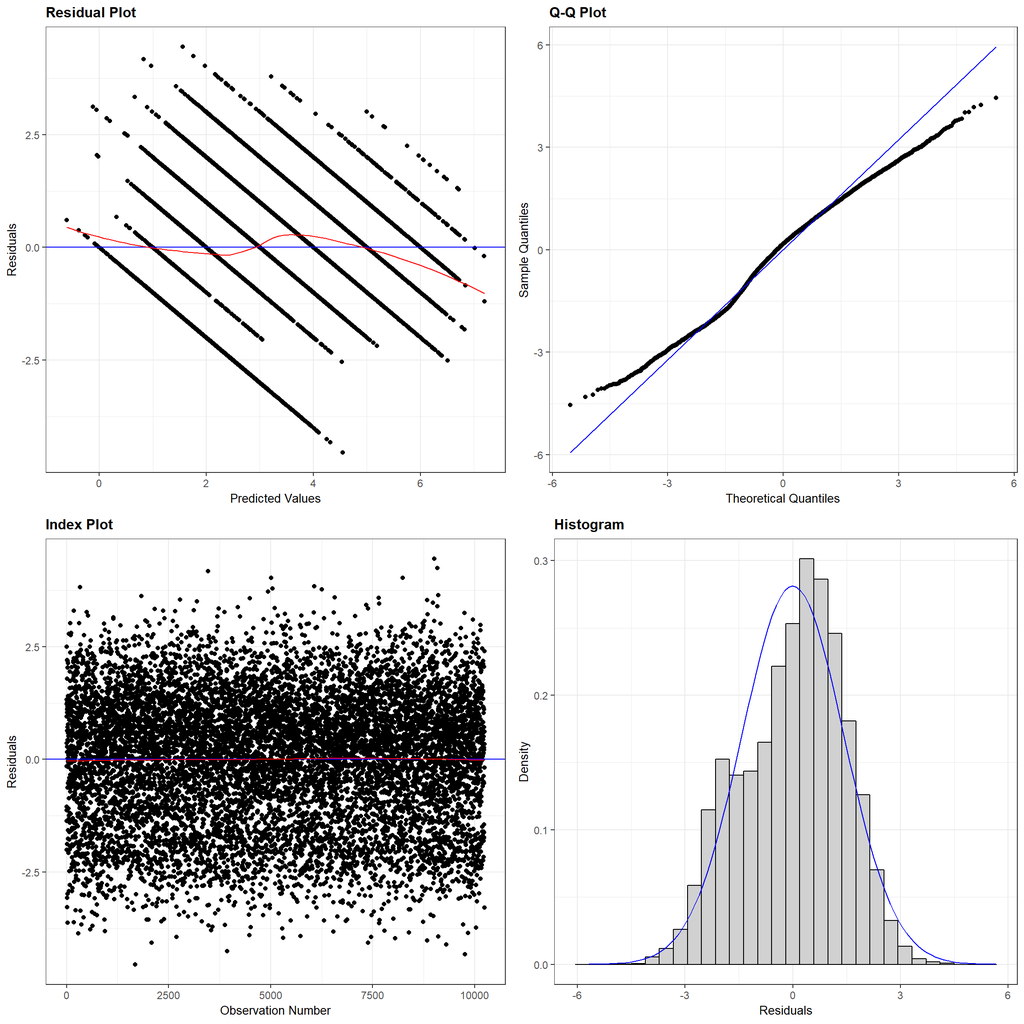

```r
resid_panel(model5, plots='default', smoother = TRUE)
```

#### RMSE Calculation

```r
### RMSE of first model - training dataset
model5_rmse_train <- mean(rmse_calc(training_set$TARGET, predict(model5, newdata = training_set)))
### RMSE of first model - test dataset
model5_rmse_test <- mean(rmse_calc(test_set$TARGET, predict(model5, newdata = test_set)))

model5_aic <- model5$aic
```

### Model 6: Multiple Linear Regression

```r
# multiple linear regression with stepwise variable selection
model6 <- stepAIC(model5, direction = "both", trace = FALSE)
summary(model6)
```

```
##
## Call:
## lm(formula = TARGET ~ VolatileAcidity + CitricAcid + Chlorides +
##     FreeSulfurDioxide + TotalSulfurDioxide + Density + pH + Sulphates +
##     Alcohol + LabelAppeal + AcidIndex + STARS, data = training_set)
##
## Residuals:
##    Min     1Q Median     3Q    Max
## -4.527 -1.021  0.177  1.033  4.440
##
## Coefficients:
##                      Estimate Std. Error t value Pr(>|t|)
## (Intercept)         3.886e+00  5.367e-01   7.241 4.78e-13 ***
## VolatileAcidity    -1.273e-01  1.800e-02  -7.074 1.60e-12 ***
## CitricAcid          2.548e-02  1.624e-02   1.569  0.11673
## Chlorides          -1.430e-01  4.374e-02  -3.270  0.00108 **
## FreeSulfurDioxide   2.800e-04  9.456e-05   2.961  0.00308 **
## TotalSulfurDioxide  1.810e-04  6.071e-05   2.981  0.00288 **
## Density            -9.334e-01  5.283e-01  -1.767  0.07732 .
## pH                 -5.715e-02  2.055e-02  -2.781  0.00542 **
## Sulphates          -3.660e-02  1.510e-02  -2.424  0.01538 *
## Alcohol             8.283e-03  3.762e-03   2.202  0.02771 *
## LabelAppeal         4.510e-01  1.654e-02  27.271  < 2e-16 ***
## AcidIndex          -2.510e-01  1.082e-02 -23.191  < 2e-16 ***
## STARS               1.155e+00  1.675e-02  68.961  < 2e-16 ***
## ---
## Signif. codes:  0 '***' 0.001 '**' 0.01 '*' 0.05 '.' 0.1 ' ' 1
##
## Residual standard error: 1.42 on 10224 degrees of freedom
## Multiple R-squared:  0.4578, Adjusted R-squared:  0.4571
## F-statistic: 719.3 on 12 and 10224 DF,  p-value: < 2.2e-16
```

#### Model Diagnostic Plots

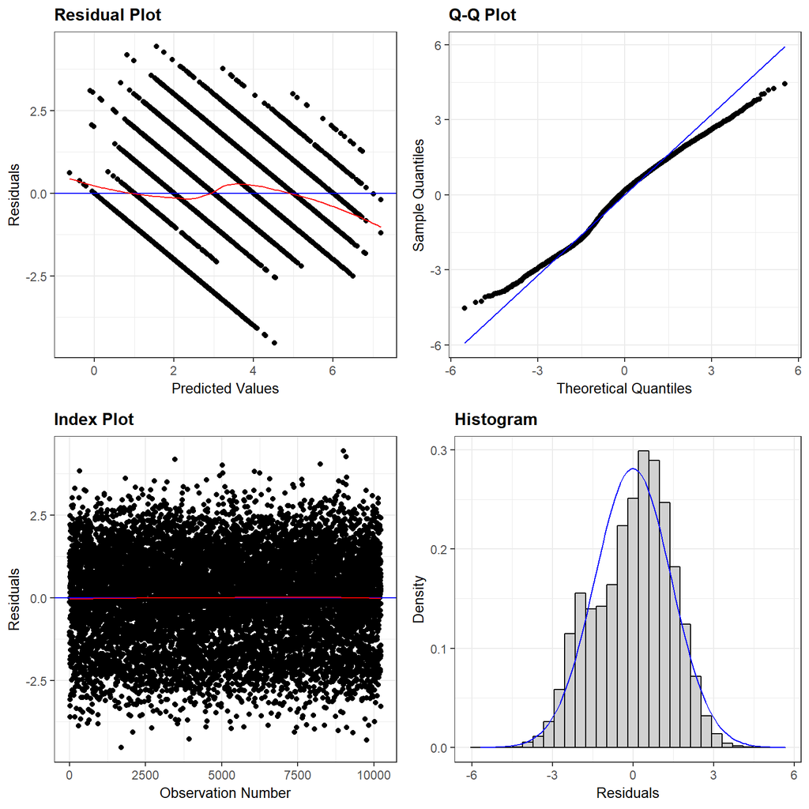

```r
resid_panel(model6, plots='default', smoother = TRUE)
```

#### RMSE Calculation

```r
### RMSE of first model - training dataset
model6_rmse_train <- mean(rmse_calc(training_set$TARGET, predict(model6, newdata = training_set)))
### RMSE of first model - test dataset
model6_rmse_test <- mean(rmse_calc(test_set$TARGET, predict(model6, newdata = test_set)))

model6_aic <- model6$aic
```

## PART IV: Selecting Models

### Compare Key Regression Model statistics

```r
# metrics
Train_RMSE <- list(model1_rmse_train, model2_rmse_train, model3_rmse_train, model4_rmse_train, model5_rmse_train, model6_rmse_train)
Test_RMSE <- list(model1_rmse_test, model2_rmse_test, model3_rmse_test, model4_rmse_test, model5_rmse_test, model6_rmse_test)

AIC <- list(model1_aic, model2_aic, model3_aic, model4_aic, model5_aic, model6_aic)

kable(rbind(Train_RMSE, Test_RMSE, AIC), col.names = c("Model 1", "Model 2", "Model 3", "Model 4", "Model 5", "Model 6"))  %>%
  kable_styling(bootstrap_options = c("striped", "hover", "condensed", "responsive")) %>%  scroll_box(width="100%",height="300px")
```

|  | Model 1 | Model 2 | Model 3 | Model 4 | Model 5 | Model 6 |
| --- | --- | --- | --- | --- | --- | --- |
| Train_RMSE | 2.61749084465551 | 1.35432902629987 | 2.61743685476711 | 2.61749006996924 | 1.41854806293486 | 1.4186294587951 |
| Test_RMSE | 2.6020239659855 | 1.35247459709401 | 2.60206289256156 | 2.60202304945068 | 1.40469654988496 | 1.40437495721672 |
| AIC | 38423.1462242275 | NULL | 38428.7871733393 | 38425.3235609569 | NULL | NULL |

### Model Prediction

```r
lm_predicted <- round(predict(poisson_model_1, newdata = eval_df),0)

lm_predicted_df <- as.data.frame(cbind(eval_df$IN, lm_predicted))

colnames(lm_predicted_df) <- c('INDEX','TARGET_WINS')

lm_predicted_df %>% kable() %>%
    kable_styling(bootstrap_options = c("striped", "hover", "condensed", "responsive")) %>%  scroll_box(width="100%",height="300px")
```

| INDEX | TARGET_WINS |
| --- | --- |
| 3 | 1 |
| 9 | 1 |
| 10 | 1 |
| 18 | 1 |
| 21 | 1 |
| 30 | 2 |
| 31 | 1 |
| 37 | 2 |
| 39 | 0 |
| 47 | 1 |
| 60 | 1 |
| 62 | 1 |
| 63 | 1 |
| 64 | 1 |
| 68 | 1 |
| 75 | 1 |
| 76 | 1 |
| 83 | 1 |
| 87 | 1 |
| 92 | 2 |
| 98 | 1 |
| 106 | 1 |
| 107 | 1 |
| 113 | 1 |
| 120 | 1 |
| 123 | 2 |
| 125 | 1 |
| 126 | 2 |
| 128 | 2 |
| 129 | 1 |

[output cut: 3305 more lines]

### Model output

```r
# export to .csv for submission
write.csv(lm_predicted_df, file = "C:/CUNY/Semester4(Spring)/DATA 621/Assignments/Homework5/Output/Wine_Sales_Prediction.csv",row.names = FALSE)
```

Our model prediction output can be found in the below GitHub location -

[Model Output](https://raw.githubusercontent.com/soumya2g/CUNYDataMiningHomeWork/master/HomeWork_5/Output/Wine_Sales_Prediction.csv)